# K03-T1-IF2220-13520114

### TUGAS BESAR IF2220 PROBABILITAS DAN STATISTIKA

### PENARIKAN KESIMPULAN DAN PENGUJIAN HIPOTESIS

### KEVIN RONI 13520114

### YOSEPH ALEXANDER SIREGAR 13520141

```python
#IMPORT MODULE & LOAD CSV
import pandas as pd
import matplotlib.pyplot as plt
import numpy as np
import seaborn as sns
import scipy.stats as scst
import math

df = pd.read_csv('water_potability.csv', header=None)
df.columns = ["iD", "pH", "Hardness", "Solids", "Chloramines", "Sulfate", "Conductivity", "OrganicCarbon", "Trihalomethanes", "Turbidity", "Potability"]
df
```

|  | iD | pH | Hardness | Solids | Chloramines | Sulfate | Conductivity | OrganicCarbon | Trihalomethanes | Turbidity | Potability |
| --- | --- | --- | --- | --- | --- | --- | --- | --- | --- | --- | --- |
| 0 | 1 | 8.316766 | 214.373394 | 22018.417441 | 8.059332 | 356.886136 | 363.266516 | 18.436524 | 100.341674 | 4.628771 | 0 |
| 1 | 2 | 9.092223 | 181.101509 | 17978.986339 | 6.546600 | 310.135738 | 398.410813 | 11.558279 | 31.997993 | 4.075075 | 0 |
| 2 | 3 | 5.584087 | 188.313324 | 28748.687739 | 7.544869 | 326.678363 | 280.467916 | 8.399735 | 54.917862 | 2.559708 | 0 |
| 3 | 4 | 10.223862 | 248.071735 | 28749.716544 | 7.513408 | 393.663396 | 283.651634 | 13.789695 | 84.603556 | 2.672989 | 0 |
| 4 | 5 | 8.635849 | 203.361523 | 13672.091764 | 4.563009 | 303.309771 | 474.607645 | 12.363817 | 62.798309 | 4.401425 | 0 |
| ... | ... | ... | ... | ... | ... | ... | ... | ... | ... | ... | ... |
| 2005 | 2006 | 8.197353 | 203.105091 | 27701.794055 | 6.472914 | 328.886838 | 444.612724 | 14.250875 | 62.906205 | 3.361833 | 1 |
| 2006 | 2007 | 8.989900 | 215.047358 | 15921.412018 | 6.297312 | 312.931022 | 390.410231 | 9.899115 | 55.069304 | 4.613843 | 1 |
| 2007 | 2008 | 6.702547 | 207.321086 | 17246.920347 | 7.708117 | 304.510230 | 329.266002 | 16.217303 | 28.878601 | 3.442983 | 1 |
| 2008 | 2009 | 11.491011 | 94.812545 | 37188.826022 | 9.263166 | 258.930600 | 439.893618 | 16.172755 | 41.558501 | 4.369264 | 1 |
| 2009 | 2010 | 6.069616 | 186.659040 | 26138.780191 | 7.747547 | 345.700257 | 415.886955 | 12.067620 | 60.419921 | 3.669712 | 1 |

2010 rows × 11 columns

#### 1. Menulis deskripsi statistika (Descriptive Statistics) dari semua kolom pada data yang bersifat numerik, terdiri dari mean, median, modus, standar deviasi, variansi, range, nilai minimum, maksimum, kuartil, IQR, skewness dan kurtosis. Boleh juga ditambahkan deskripsi lain.

```python
df1 = df.drop(columns=["iD", "Potability"])
stats = pd.DataFrame()
stats["Mean"] = df1.mean()
stats["Median"] = df1.median()
stats["Modus"] = df1.mode().loc[0].values
stats["Standard Deviation"] = df1.std()
stats["Variance"] = df1.var()
stats["Range"] = df1.max() - df1.min()
stats["Min"] = df1.min()
stats["Max"] = df1.max()
stats["Q1"] = df1.quantile(0.25)
stats["Q3"] = df1.quantile(0.75)
stats["IQR"] = stats["Q3"] - stats["Q1"]
stats["Skewness"] = df1.skew()
stats["Kurtosis"] = df1.kurt()
stats
```

|  | Mean | Median | Modus | Standard Deviation | Variance | Range | Min | Max | Q1 | Q3 | IQR | Skewness | Kurtosis |
| --- | --- | --- | --- | --- | --- | --- | --- | --- | --- | --- | --- | --- | --- |
| pH | 7.087193 | 7.029490 | 0.227499 | 1.572803 | 2.473709e+00 | 13.772501 | 0.227499 | 14.000000 | 6.090785 | 8.053006 | 1.962221 | 0.048535 | 0.626904 |
| Hardness | 195.969209 | 197.203525 | 73.492234 | 32.643166 | 1.065576e+03 | 243.845890 | 73.492234 | 317.338124 | 176.740657 | 216.447589 | 39.706932 | -0.085321 | 0.525480 |
| Solids | 21904.673439 | 20926.882155 | 320.942611 | 8625.397911 | 7.439749e+07 | 56167.729801 | 320.942611 | 56488.672413 | 15614.412962 | 27170.534649 | 11556.121687 | 0.591011 | 0.337320 |
| Chloramines | 7.134322 | 7.142014 | 1.390871 | 1.585214 | 2.512904e+00 | 11.736129 | 1.390871 | 13.127000 | 6.138326 | 8.109933 | 1.971607 | 0.013003 | 0.549782 |
| Sulfate | 333.211376 | 332.214113 | 129.000000 | 41.211111 | 1.698356e+03 | 352.030642 | 129.000000 | 481.030642 | 307.626986 | 359.268147 | 51.641161 | -0.045728 | 0.786854 |
| Conductivity | 426.476708 | 423.438372 | 201.619737 | 80.701872 | 6.512792e+03 | 551.722883 | 201.619737 | 753.342620 | 366.619219 | 482.209772 | 115.590553 | 0.268012 | -0.237206 |
| OrganicCarbon | 14.357940 | 14.323286 | 2.200000 | 3.325770 | 1.106075e+01 | 24.806707 | 2.200000 | 27.006707 | 12.122530 | 16.683562 | 4.561031 | -0.020220 | 0.031018 |
| Trihalomethanes | 66.400717 | 66.482041 | 8.577013 | 16.081109 | 2.586021e+02 | 115.422987 | 8.577013 | 124.000000 | 55.949993 | 77.294613 | 21.344620 | -0.051383 | 0.223017 |
| Turbidity | 3.969497 | 3.967374 | 1.450000 | 0.780471 | 6.091350e-01 | 5.044749 | 1.450000 | 6.494749 | 3.442882 | 4.514663 | 1.071781 | -0.032266 | -0.049831 |

## 2. Membuat Visualisasi plot distribusi, dalam bentuk histogram dan boxplot untuk setiap kolom numerik. Berikan uraian penjelasan kondisi setiap kolom berdasarkan kedua plot tersebut.

### a. Kolom PH

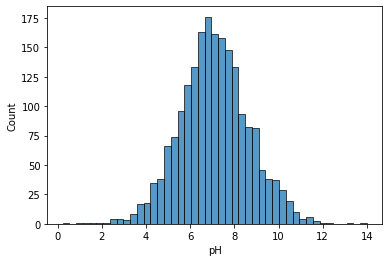

```python
sns.histplot(data = df["pH"])
plt.show()
```

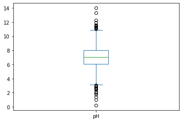

```python
df["pH"].plot(kind="box")
plt.show()
```

Hal ini menunjukkan nilai pH yang terdapat pada dataset akan tersebar di nilai 7.

Skewness pada tabel pH cenderung positif dan standar deviasinya sangat kecil karena terlihat pada grafik, data tidak tersebar jauh dari nilai 7.

### b. Kolom Hardness

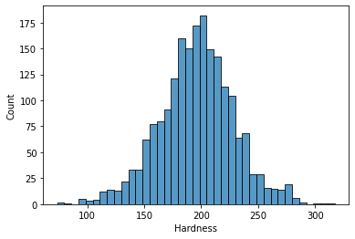

```python
sns.histplot(data = df["Hardness"])
plt.show()
```

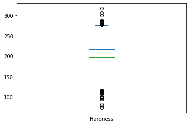

```python
df["Hardness"].plot(kind="box")
plt.show()
```

Hal ini menunjukkan nilai Hardness yang terdapat pada dataset akan tersebar di nilai 200.

Skewness pada tabel Hardness cenderung negatif dan standar deviasinya tidak begitu besar.

Berdasarkan box plot, outliers tersebar cukup rata di atas nilai maksimum dan di bawah nilai minimum .

### c. Kolom Solids

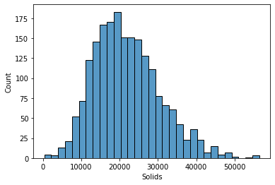

```python
sns.histplot(data = df["Solids"])
```

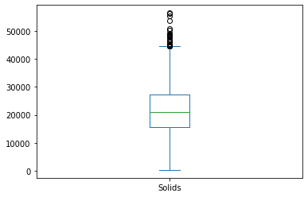

```python
df["Solids"].plot(kind="box")
```

Skewness pada tabel Solids sangat positif dan standar deviasinya relatif besar karena terlihat pada grafik, data memiliki banyak variasi di sebelah kanan.

Nilai mean dan median terletak di sekitar nilai 21.000 berdasarkan grafik

Berdasarkan box plot, tidak terdapat outliers dibawah dari nilai minimum .

### d. Kolom Chloramines

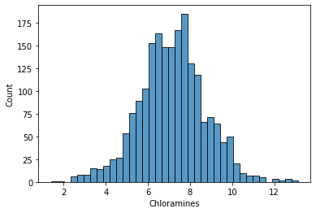

```python
sns.histplot(data = df["Chloramines"])
```

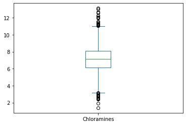

```python
df["Chloramines"].plot(kind="box")
```

Hal ini menunjukkan nilai Chloramines yang terdapat pada dataset akan tersebar di nilai 7.

Skewness pada tabel Chloramines cenderung positif dan standar deviasinya kecil karena terlihat pada grafik, data tidak tersebar jauh dari nilai 7.

Berdasarkan box plot, terdapat outliers paling jauh dari nilai minimum diantara nilai 0 - 2 .

### e. Kolom Sulfate

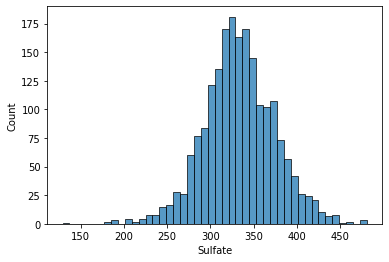

```python
sns.histplot(data = df["Sulfate"])
```

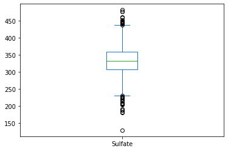

```python
df["Sulfate"].plot(kind="box")
```

Hal ini menunjukkan nilai Sulfate yang terdapat pada dataset akan tersebar di nilai 320.

Skewness pada tabel Sulfate cenderung negatif dan standar deviasinya tidak begitu besar.

Berdasarkan box plot, terdapat outliers paling jauh dari nilai minimum diantara nilai 0 - 150 .

### f. Kolom Conductivity

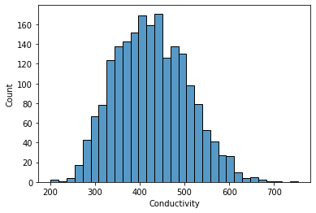

```python
sns.histplot(data = df["Conductivity"])
```

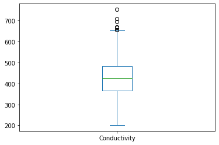

```python
df["Conductivity"].plot(kind="box")
```

Skewness pada tabel Conductivity terlihat positif dan standar deviasinya relatif cukup besar karena terlihat pada grafik, data memiliki banyak variasi di sebelah kanan.

Nilai mean dan median terletak di sekitar nilai 420 berdasarkan grafik

Berdasarkan box plot, tidak terdapat outliers dibawah dari nilai minimum .

### g. Kolom OrganicCarbon

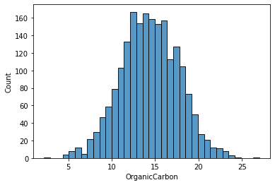

```python
sns.histplot(data = df["OrganicCarbon"])
```

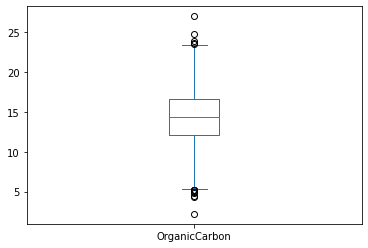

```python
df["OrganicCarbon"].plot(kind="box")
```

Hal ini menunjukkan nilai OrganicCarbon yang terdapat pada dataset akan tersebar di nilai 14.

Skewness pada tabel OrganicCarbon cenderung negatif dan standar deviasinya sangat kecil karena terlihat pada grafik, data tidak tersebar jauh dari nilai 14.

Berdasarkan box plot, terdapat outliers yang cukup jauh di atas nilai maksimum dan di bawah nilai minimum .

### h. Kolom Trihalomethanes

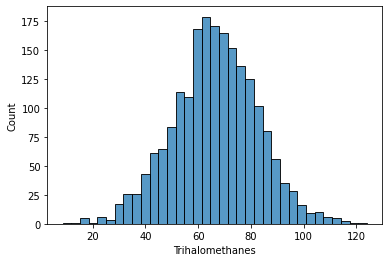

```python
sns.histplot(data = df["Trihalomethanes"])
```

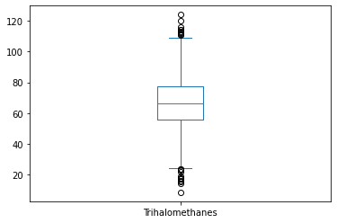

```python
df["Trihalomethanes"].plot(kind="box")
```

Hal ini menunjukkan nilai Trihalomethanes yang terdapat pada dataset akan tersebar di nilai 65.

Skewness pada tabel Trihalomethanes cenderung negatif dan standar deviasinya tidak begitu besar.

Berdasarkan box plot, outliers tersebar cukup rata di atas nilai maksimum dan di bawah nilai minimum .

### i. Kolom Turbidity

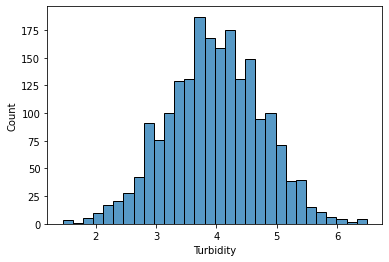

```python
sns.histplot(data = df["Turbidity"])
plt.show()
```

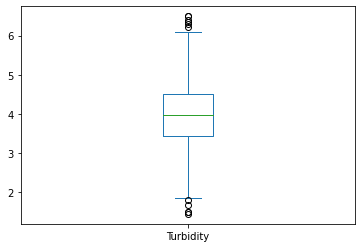

```python
df["Turbidity"].plot(kind="box")
plt.show()
```

Hal ini menunjukkan nilai Turbidity yang terdapat pada dataset akan tersebar di nilai 4.

Skewness pada tabel Turbidity cenderung simetris dan standar deviasinya sangat kecil karena terlihat pada grafik, data tidak tersebar jauh dari nilai 4.

Berdasarkan box plot, outliers tersebar cukup rata di atas nilai maksimum dan di bawah nilai minimum .

## 3. Menentukan setiap kolom numerik berdistribusi normal atau tidak. Gunakan normality test yang dikaitkan dengan histogram plot.

```python
def normality_test(column):
    stat, p_value = scst.normaltest(df[column])
    print("p-value       = ", p_value)
    if(p_value < 0.05):
        print("Kolom %s tidak berdistribusi normal" %(column))
    else:
        print("Kolom %s berdistribusi normal" %(column))
    sns.distplot(df[column])
    plt.show()
```

```
p-value       =  2.6514813346797777e-05
Kolom pH tidak berdistribusi normal
```

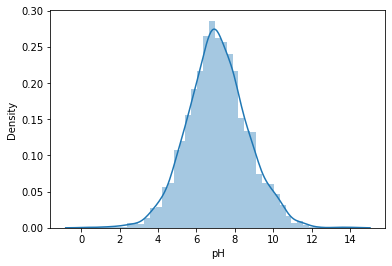

```
p-value       =  0.00013442428699593753
Kolom Hardness tidak berdistribusi normal
```

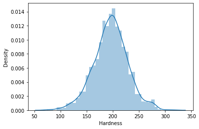

```
p-value       =  2.0796613688739523e-24
Kolom Solids tidak berdistribusi normal
```

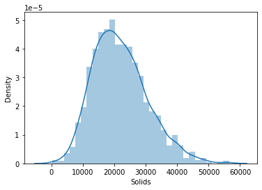

```
p-value       =  0.0002504831654753917
Kolom Chloramines tidak berdistribusi normal
```

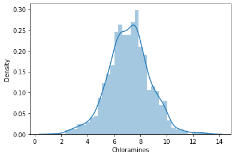

```
p-value       =  4.4255936678013136e-07
Kolom Sulfate tidak berdistribusi normal
```

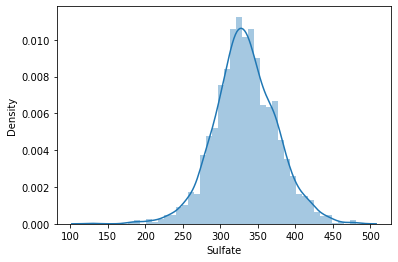

```
p-value       =  4.39018078287845e-07
Kolom Conductivity tidak berdistribusi normal
```

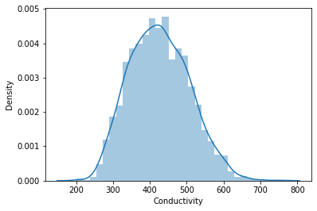

```
p-value       =  0.8825496581408284
Kolom OrganicCarbon berdistribusi normal
```

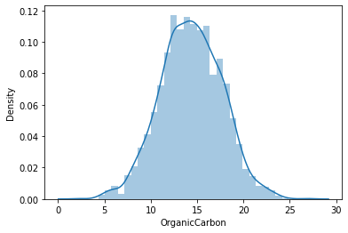

```
p-value       =  0.1043598441875204
Kolom Trihalomethanes berdistribusi normal
```

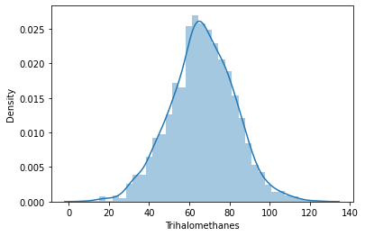

```
p-value       =  0.7694717369961169
Kolom Turbidity berdistribusi normal
```

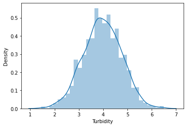

```python
normality_test("pH")
normality_test("Hardness")
normality_test("Solids")
normality_test("Chloramines")
normality_test("Sulfate")
normality_test("Conductivity")
normality_test("OrganicCarbon")
normality_test("Trihalomethanes")
normality_test("Turbidity")
```

## 4. Melakukan test hipotesis 1 sampel, dengan menuliskan 6 langkah testing dan menampilkan juga boxplotnya untuk kolom/bagian yang bersesuaian.

Akan dilakukan 6 langkah testing, yaitu sebagai berikut:

1. Tentukan Hipotesis nol (H0 : θ = θ0 ), dimana θ bisa berupa μ, σ 2 , p, atau data lain berdistribusi

tertentu (normal, binomial, dsc.).

1. Pilih hipotesis alternatif H1 salah dari dari θ > θ0 , θ < θ0 , atau θ ≠ θ0 .
2. Tentukan tingkat signifikan α.
3. Tentukan uji statistik yang sesuai dan tentukan daerah kritis. Titik kritis didapat berdasarkan $z_{\alpha}$ atau $z_\frac{\alpha}{2}$. Tergantung pada hipotesis yang dipilih, titik kritis akan berbeda.
4. Hitung nilai uji statistik dari data sample. Hitung p-value sesuai dengan uji statistik yang digunakan.
5. Ambil keputusan dengan TOLAK H0 jika nilai uji terletak di daerah kritis atau dengan tes signifikan, TOLAK H0 jika p-value lebih kecil dibanding tingkat signifikansi α yang diinginkan.

```python
def uji_statistik(data, H0, opt, alpha, Z):
    result = scst.ttest_1samp(data, H0, alternative=opt)
    print("Z                     :", result.statistic)
    print("p-value               :", result.pvalue)
    if (result.statistic > Z):
        print("H0 ditolak karena Z terletak di daerah kritis")
    else:
        print("H0 diterima karena Z terletak di luar daerah kritis")
    if (result.pvalue < alpha):
        print("H0 ditolak karena p-value lebih kecil dari tingkat signifikasi yang diinginkan", alpha)
    else:
        print("H0 diterima karena p-value lebih besar dari tingkat signifikasi yang diinginkan", alpha)

def uji_statistik_2(data, H0, opt, alpha, Z):
    result = scst.ttest_1samp(data, H0, alternative=opt)
    print("Z                     :", result.statistic)
    print("p-value               :", result.pvalue)
    if (result.statistic > Z or result.statistic < -1*Z):
        print("H0 ditolak karena Z terletak di daerah kritis")
    else:
        print("H0 diterima karena Z terletak di luar daerah kritis")
    if (result.pvalue < alpha):
        print("H0 ditolak karena p-value lebih kecil dari tingkat signifikasi yang diinginkan", alpha)
    else:
        print("H0 diterima karena p-value lebih besar dari tingkat signifikasi yang diinginkan", alpha)

def uji_statistik_proporsi(p,p0,n,Z):
    result = (p-p0)/math.sqrt(p0*(1-p0)/n)
    print("Z                     :", result)
    print("p-value               :", 2*count_pValue(result))
    if (result > Z or result < -1*Z):
        print("H0 ditolak karena Z terletak di daerah kritis")
    else:
        print("H0 diterima karena Z terletak di luar daerah kritis")

def uji_statistik_proporsi2(p,p0,n,Z):
    result = (p-p0)/math.sqrt(p0*(1-p0)/n)
    print("Z                     :", result)
    print("p-value               :", count_pValue(result))
    if (result < -1*Z):
        print("H0 ditolak karena Z terletak di daerah kritis")
    else:
        print("H0 diterima karena Z terletak di luar daerah kritis")

def count_pValue(Z):
    return (1 - scst.norm.cdf(abs(Z)))
```

a. Nilai Rata-rata pH di atas 7?

```
H0                    : μ = 7
H1                    : μ > 7
Tingkat signifikasi(α): 0.05
Daerah kritis         : Z > 1.645
Z                     : 2.485445147379887
p-value               : 0.006509872359240925
H0 ditolak karena Z terletak di daerah kritis
H0 ditolak karena p-value lebih kecil dari tingkat signifikasi yang diinginkan 0.05
```

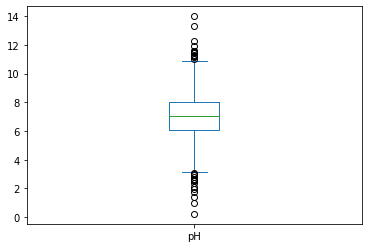

```python
print("H0                    : μ = 7")
print("H1                    : μ > 7")
alpha = 0.05
print("Tingkat signifikasi(α):", alpha)
Z = 1.645
print("Daerah kritis         : Z >", Z)
uji_statistik(df["pH"], 7, "greater", alpha, Z)
df["pH"].plot(kind="box")
plt.show()
```

Kesimpulannya, H0 akan ditolak dan menerima H1 karena H0 terletak di daerah kritis dan diperkuat oleh nilai p-value yang lebih kecil dari tingkat signifikasi. Maka dapat dikatakan nilai rata-rata pH di atas 7.

b. Nilai Rata-rata Hardness tidak sama dengan 205?

```
H0                    : μ = 205
H1                    : μ != 205
Tingkat signifikasi(α): 0.05
Daerah kritis         : Z > 1.96 or Z < -1.96
Z                     : -12.403137170010732
p-value               : 4.299181043195823e-34
H0 ditolak karena Z terletak di daerah kritis
H0 ditolak karena p-value lebih kecil dari tingkat signifikasi yang diinginkan 0.05
```

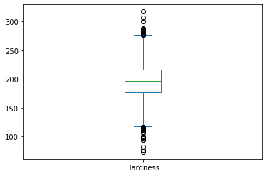

```python
print("H0                    : μ = 205")
print("H1                    : μ != 205")
alpha = 0.05
print("Tingkat signifikasi(α):", alpha)
Z = 1.96
print("Daerah kritis         : Z > " +str(Z)+ " or Z < -" +str(Z))
uji_statistik_2(df["Hardness"], 205, "two-sided", alpha, Z)
df["Hardness"].plot(kind="box")
plt.show()
```

Kesimpulannya H0 akan ditolak dan menerima H1 karena H0 terletak di daerah kritis dan diperkuat oleh nilai p-value yang lebih kecil dari tingkat signifikasi. Maka dapat dikatakan nilai rata-rata Hardness tidak sama dengan 205.

c. Nilai Rata-rata 100 baris pertama kolom Solids bukan 21900?

```
H0                    : μ = 21900
H1                    : μ != 21900
Tingkat signifikasi(α): 0.05
Daerah kritis         : Z > 1.96 or Z < -1.96
Z                     : 0.5636797715721551
p-value               : 0.5742467134052605
H0 diterima karena Z terletak di luar daerah kritis
H0 diterima karena p-value lebih besar dari tingkat signifikasi yang diinginkan 0.05
```

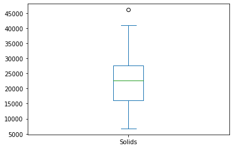

```python
print("H0                    : μ = 21900")
print("H1                    : μ != 21900")
alpha = 0.05
print("Tingkat signifikasi(α):", alpha)
Z = 1.96
print("Daerah kritis         : Z > " +str(Z)+ " or Z < -" +str(Z))
df_100 = df.head(100)
uji_statistik_2(df_100["Solids"], 21900, "two-sided", alpha, Z)
df_100["Solids"].plot(kind="box")
plt.show()
```

Kesimpulannya H0 akan diterima karena H0 terletak di luar daerah kritis dan diperkuat oleh nilai p-value yang lebih besar dari tingkat signifikasi. Maka tidak dapat dikatakan bahwa nilai rata-rata 100 baris pertama kolom Solids bukan 21900.

d. Proporsi nilai Conductivity yang lebih dari 450, adalah tidak sama dengan 10%?

```
H0                    : P0 = 0.1
H1                    : P1 != 0.1
Tingkat signifikasi(α): 0.05
Daerah kritis         : Z > 1.96 or Z < -1.96
Z                     : 40.44637613158932
p-value               : 0.0
H0 ditolak karena Z terletak di daerah kritis
```

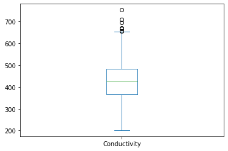

```python
sample = []
for row in df["Conductivity"]:
    if (row > 450):
        sample.append(row)

print("H0                    : P0 = 0.1")
print("H1                    : P1 != 0.1")
alpha = 0.05
print("Tingkat signifikasi(α):", alpha)
Z = 1.96
print("Daerah kritis         : Z > " +str(Z)+ " or Z < -" +str(Z))
uji_statistik_proporsi(len(sample)/len(df), 0.1, len(df), Z)
df["Conductivity"].plot(kind="box")
plt.show()
```

Kesimpulannya H0 akan ditolak dan menerima H1 karena H0 terletak di daerah kritis. Maka dapat dikatakan proporsi nilai Conductivity yang lebih dari 450, adalah tidak sama dengan 10%.

e. Proporsi nilai Trihalomethanes yang kurang dari 40, adalah kurang dari 5%?

[output not shown]

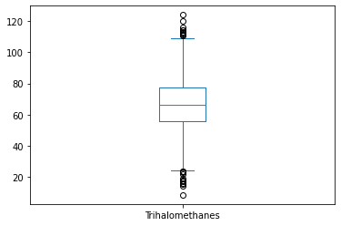

```python
sample2 = []
for row in df["Trihalomethanes"]:
    if (row < 40):
        sample2.append(row)
print(len(sample2))
print("H0                    : P0 = 0.05")
print("H1                    : P1 < 0.05")
alpha = 0.05
print("Tingkat signifikasi(α):", alpha)
Z = 1.645
print("Daerah kritis         : Z < -" +str(Z))
uji_statistik_proporsi2(len(sample2)/len(df), 0.05, len(df), Z)
df["Trihalomethanes"].plot(kind="box")
plt.show()
```

Kesimpulannya H0 akan diterima karena H0 terletak di luar daerah kritis. Maka tidak dapat dikatakan nilai Trihalomethanes yang kurang dari 40, adalah kurang dari 5%